# GWAS Visualization in R

Keith Mitchel, UC Davis Bioinformatics Core

7/7/2021

# We will need to get the tdt results for the data

For a comparison, a sample dataset is provided in order to show what all chromosomes would look like. We will create some visualization with this as well.

```r
head(gwasResults)
```

```
##   SNP CHR BP         P
## 1 rs1   1  1 0.9148060
## 2 rs2   1  2 0.9370754
## 3 rs3   1  3 0.2861395
## 4 rs4   1  4 0.8304476
## 5 rs5   1  5 0.6417455
## 6 rs6   1  6 0.5190959
```

Lets read in the TDT results - The adjusted file is a bit smaller here since the NA values cannot be adjusted and are ommitted. So lets merge and only keep values that exist in the adjusted file, but lets add the frequency or MAF

```r
tdtfrq <- read.csv("data_analysis/tdtfrq.csv")
head(tdtfrq)
```

```
##   CHR     SNP A1 A2      MAF NCHROBS
## 1  21 5034209  A  G 0.003571     280
## 2  21 5034244  T  C 0.007042     284
## 3  21 5063575  T  C 0.003497     286
## 4  21 5063806  T  C 0.003448     290
## 5  21 5063842  A  G 0.010420     288
## 6  21 5089937  C  T 0.017240     290
```

```r
tdtadj <- read.csv("data_analysis/tdtadj.csv", row.names=NULL)
head(tdtadj)
```

```
##   CHR      SNP     UNADJ       GC BONF HOLM SIDAK_SS SIDAK_SD FDR_BH FDR_BY
## 1  21  7946755 3.738e-05 0.005365    1    1   0.9714   0.9714 0.3734      1
## 2  21  7946763 3.738e-05 0.005365    1    1   0.9714   0.9714 0.3734      1
## 3  21  7946728 6.334e-05 0.006911    1    1   0.9976   0.9976 0.3734      1
## 4  21  7946741 6.334e-05 0.006911    1    1   0.9976   0.9976 0.3734      1
## 5  21  7946744 6.334e-05 0.006911    1    1   0.9976   0.9976 0.3734      1
## 6  21 26266437 8.770e-05 0.008081    1    1   0.9998   0.9998 0.3734      1
```

Lets merge our frequences with the TDT results.

```r
cleantdt <- merge(tdtfrq , tdtadj, by=c("CHR","SNP"))
head(cleantdt)
```

```
##   CHR      SNP A1 A2      MAF NCHROBS  UNADJ     GC BONF HOLM SIDAK_SS SIDAK_SD
## 1  21 10000132 AT  A 0.003448     290 0.3173 0.4995    1    1        1        1
## 2  21 10000176 AT  A 0.003448     290 0.3173 0.4995    1    1        1        1
## 3  21 10000297  A  G 0.006897     290 0.3173 0.4995    1    1        1        1
## 4  21 10000415  G  T 0.003448     290 1.0000 1.0000    1    1        1        1
## 5  21 10000434  A  G 0.003448     290 0.3173 0.4995    1    1        1        1
## 6  21 10000714  A  G 0.489600     288 0.7194 0.8083    1    1        1        1
##   FDR_BH FDR_BY
## 1 0.3734      1
## 2 0.3734      1
## 3 0.3734      1
## 4 1.0000      1
## 5 0.3734      1
## 6 0.7983      1
```

Lets read in the annotation information

```r
anno <- read.csv('data_analysis/query.output.genome_summary.csv')
head(anno)
```

```
##   Chr   Start     End Ref Alt Func.refGene     Gene.refGene
## 1  21 5034209 5034209   G   A     intronic           ICOSLG
## 2  21 5034244 5034244   C   T     intronic           ICOSLG
## 3  21 5063575 5063575   C   T   intergenic ICOSLG;LINC01678
## 4  21 5063806 5063806   C   T   intergenic ICOSLG;LINC01678
## 5  21 5063842 5063842   G   A   intergenic ICOSLG;LINC01678
## 6  21 5089937 5089937   T   C   intergenic ICOSLG;LINC01678
##      GeneDetail.refGene ExonicFunc.refGene AAChange.refGene X1000G_ALL
## 1
## 2
## 3 dist=22907;dist=38485
## 4 dist=23138;dist=38254
## 5 dist=23174;dist=38218
## 6 dist=49269;dist=12123
##   X1000G_AFR X1000G_AMR X1000G_EAS X1000G_EUR X1000G_SAS ExAC_Freq ExAC_AFR
## 1
## 2
## 3
## 4
## 5
## 6
##   ExAC_AMR ExAC_EAS ExAC_FIN ExAC_NFE ExAC_OTH ExAC_SAS ESP6500si_ALL
## 1
## 2
## 3
## 4
## 5
## 6
##   ESP6500si_AA ESP6500si_EA CG46 NCI60 dbSNP COSMIC_ID COSMIC_DIS ClinVar_SIG
## 1
## 2
## 3
## 4
## 5
## 6
##   ClinVar_DIS ClinVar_ID ClinVar_DB ClinVar_DBID GWAS_DIS GWAS_OR GWAS_BETA
## 1
## 2
## 3
## 4
```

[output cut: 162 more lines]

[output not shown]

There seem to be some NA values produced by plink for TDT.. why might this be?

```r
final <- merge(cleantdt, anno, by.x=c("CHR","SNP"), by.y=c("Chr", "Start"))
head(final)
```

```
##   CHR      SNP A1 A2      MAF NCHROBS  UNADJ     GC BONF HOLM SIDAK_SS SIDAK_SD
## 1  21 10000132 AT  A 0.003448     290 0.3173 0.4995    1    1        1        1
## 2  21 10000176 AT  A 0.003448     290 0.3173 0.4995    1    1        1        1
## 3  21 10000297  A  G 0.006897     290 0.3173 0.4995    1    1        1        1
## 4  21 10000415  G  T 0.003448     290 1.0000 1.0000    1    1        1        1
## 5  21 10000434  A  G 0.003448     290 0.3173 0.4995    1    1        1        1
## 6  21 10000714  A  G 0.489600     288 0.7194 0.8083    1    1        1        1
##   FDR_BH FDR_BY      End Ref Alt Func.refGene   Gene.refGene
## 1 0.3734      1 10000132   -   T   intergenic LINC01667;BAGE
## 2 0.3734      1 10000176   -   T   intergenic LINC01667;BAGE
## 3 0.3734      1 10000297   G   A   intergenic LINC01667;BAGE
## 4 1.0000      1 10000415   T   G   intergenic LINC01667;BAGE
## 5 0.3734      1 10000434   G   A   intergenic LINC01667;BAGE
## 6 0.7983      1 10000714   G   A   intergenic LINC01667;BAGE
##        GeneDetail.refGene ExonicFunc.refGene AAChange.refGene X1000G_ALL
```

[output cut: 209 more lines]

What are the top dbSNP ids for the UNADJ p values

```r
annotate <- head(final %>% arrange(UNADJ), 20)$dbSNP
annotate <- annotate[annotate != '' & annotate !='.']
```

Make the Manhattan plot on the final dataset Make the Manhattan plot on the gwasResults dataset

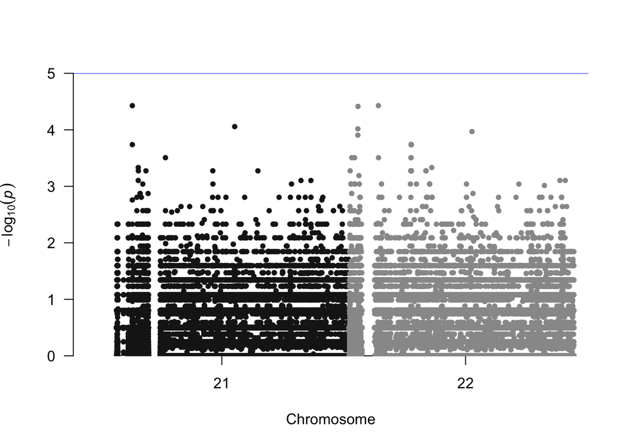

```r
manhattan(final, chr="CHR", bp="SNP", snp="dbSNP", p="UNADJ" )
```

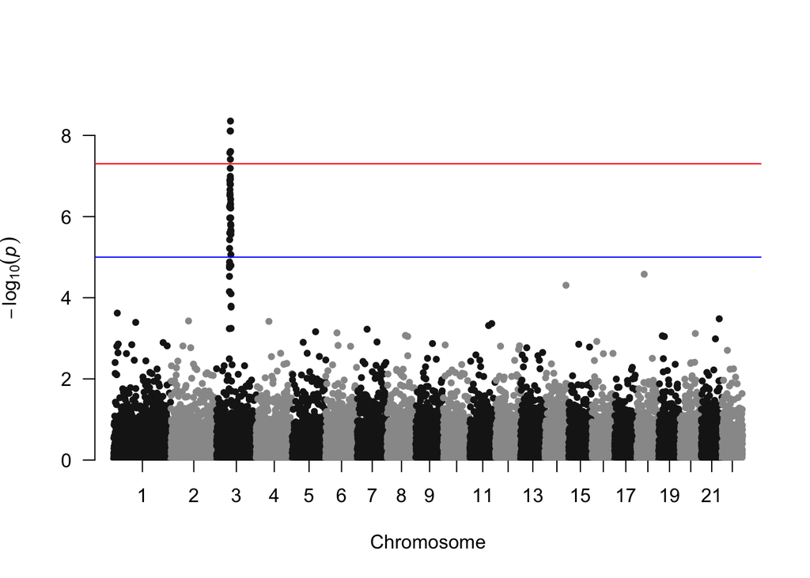

```r
manhattan(gwasResults)
```

A list of SNP of interest is provided with the library: Let’s highlight them, with a bit of customization on the plot By default -log base 10 is used to transform our p-values. Lets see why

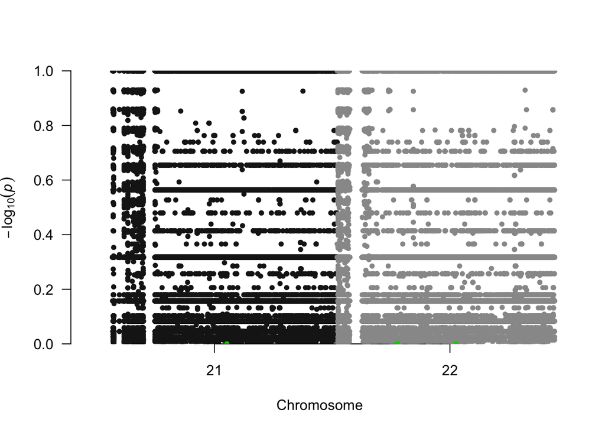

```r
manhattan(final,  chr="CHR", bp="SNP", snp="dbSNP", p="UNADJ", highlight = annotate, logp=F)
```

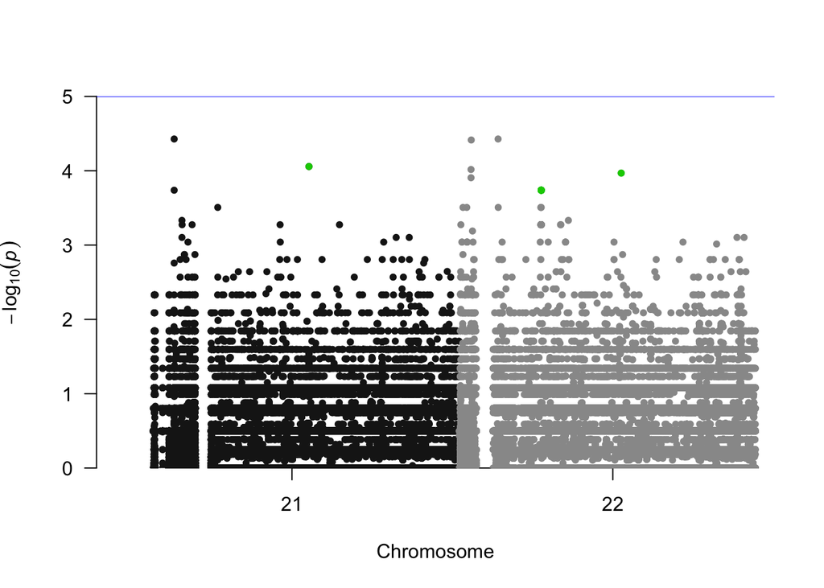

```r
manhattan(final,  chr="CHR", bp="SNP", snp="dbSNP", p="UNADJ", highlight = annotate, logp=T)
```

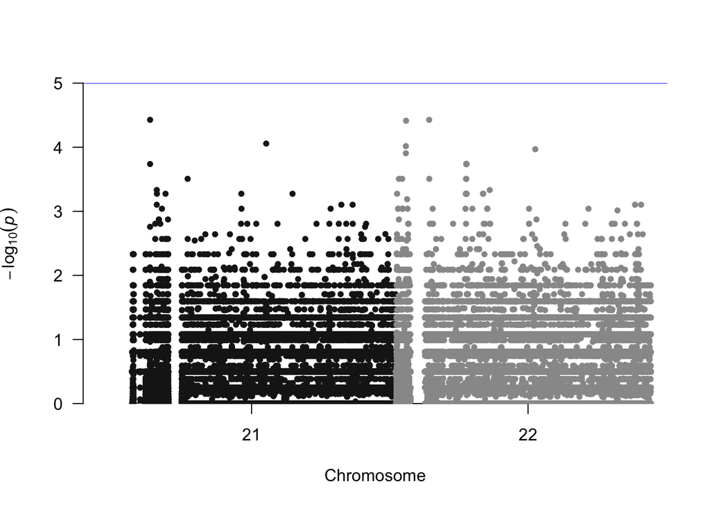

```r
manhattan(final,  chr="CHR", bp="SNP", snp="dbSNP", p="UNADJ", annotatePval = 0.5)
```

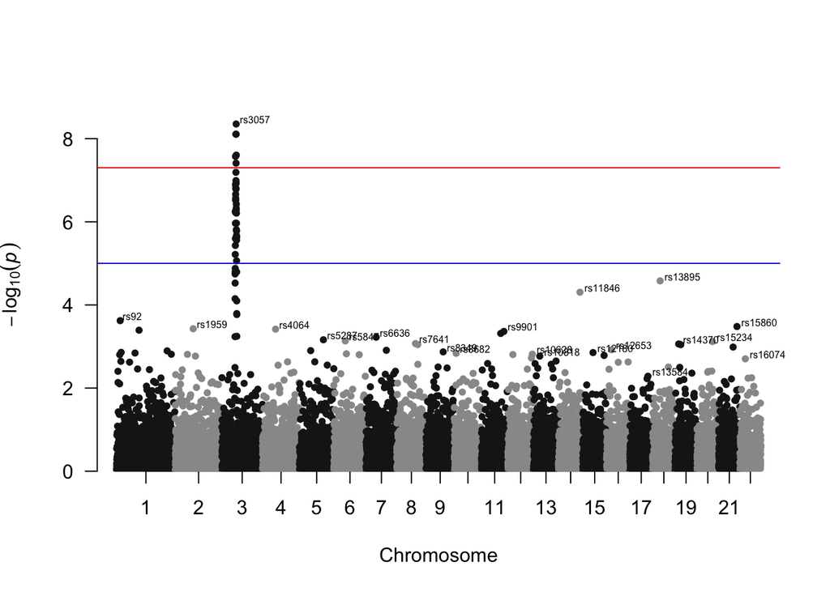

```r
manhattan(gwasResults, annotatePval = 0.05)
```

We have tons of other metadata, what else would be interesting to explore?

## circular version with CMplot

The CMplot library by Lilin Yin is a good choice if you want to make a circular version of your manhattanplot. I believe than doing a circular version makes sense: it gives less space to all the non significant SNPs that do not interest us, and gives more space for the significant association. Moreover, the CMplot makes their realization straightforward.

```
##  Circular-Manhattan Plotting P.
##  Plots are stored in: /Users/keithmitchell/Desktop/Repositories/2021-July-Genome-Wide-Association-Studies
```

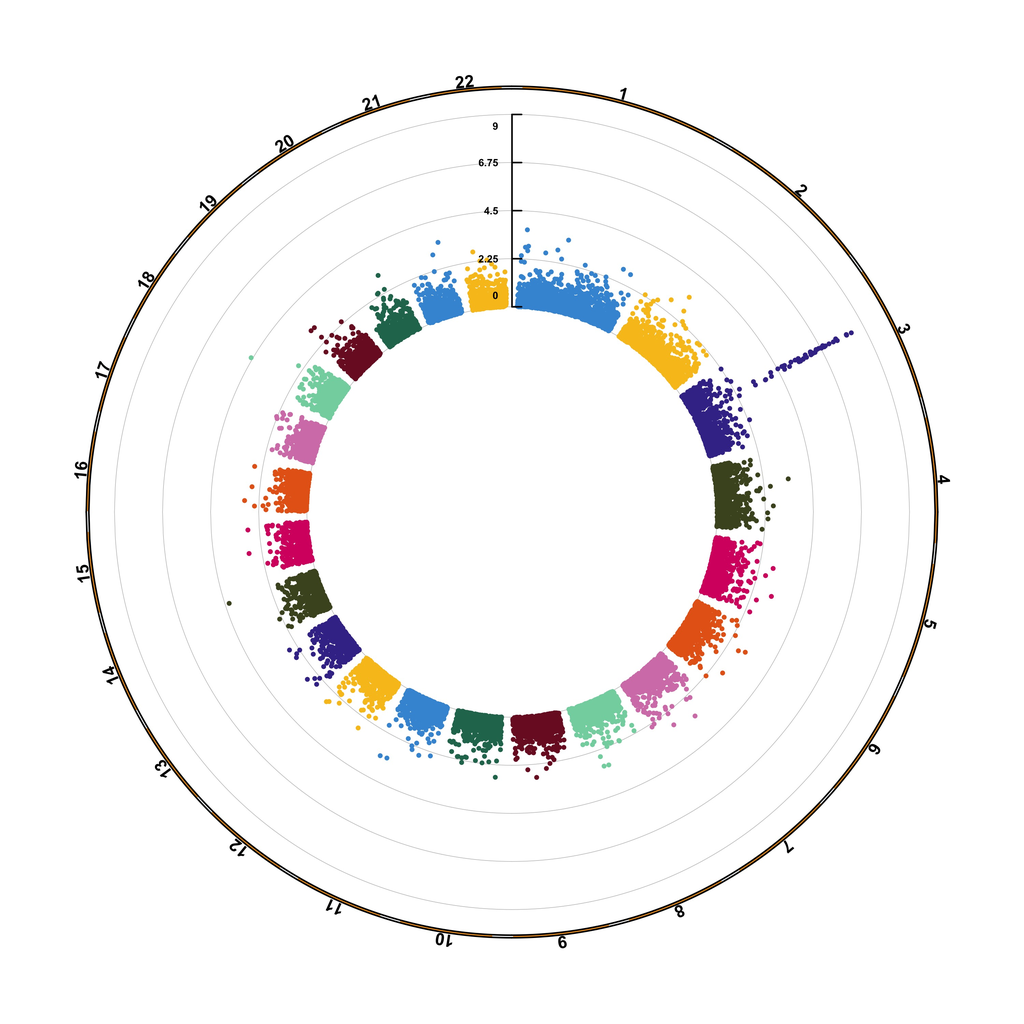

```r
library("CMplot")
CMplot(gwasResults, plot.type="c", r=1.6, cir.legend=TRUE,
        outward=TRUE, cir.legend.col="black", cir.chr.h=.1 ,chr.den.col="orange", file="jpg",
        memo="", dpi=300, chr.labels=seq(1,22))
```

## Explore the metadata:

- MAF

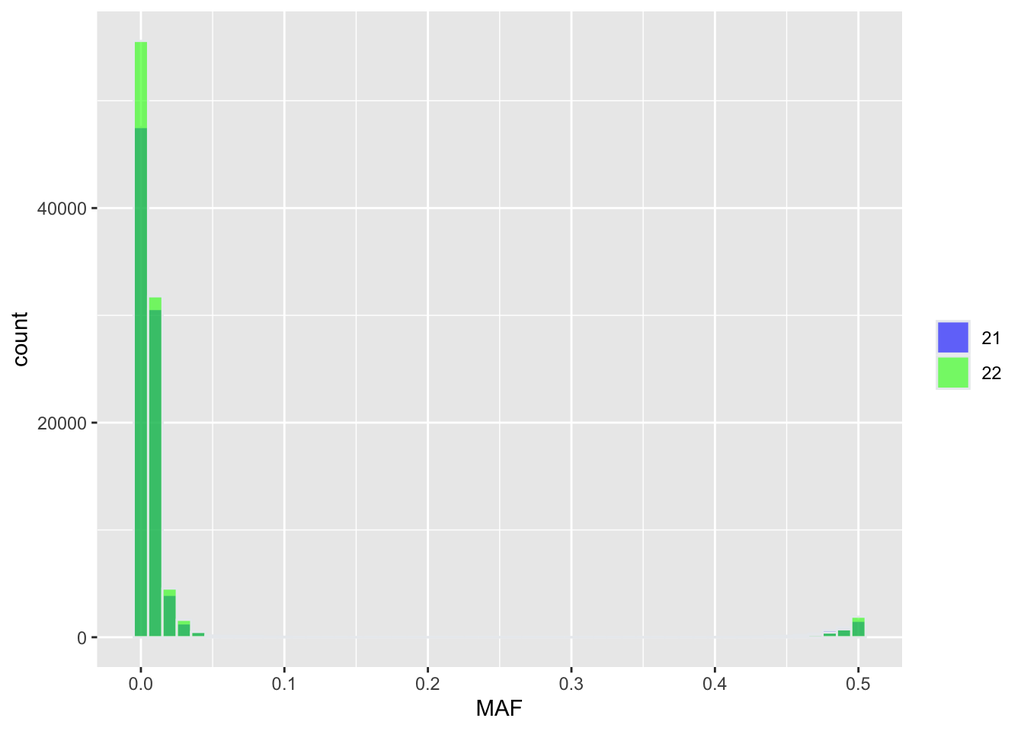

```r
p <- ggplot(final, aes(x=MAF, fill=as.factor(CHR))) + geom_histogram( color="#e9ecef", binwidth = 0.01, alpha=0.6, position = 'identity') +
    scale_fill_manual(values=c("blue", "green")) +
    labs(fill="")
p
```

- population MAF

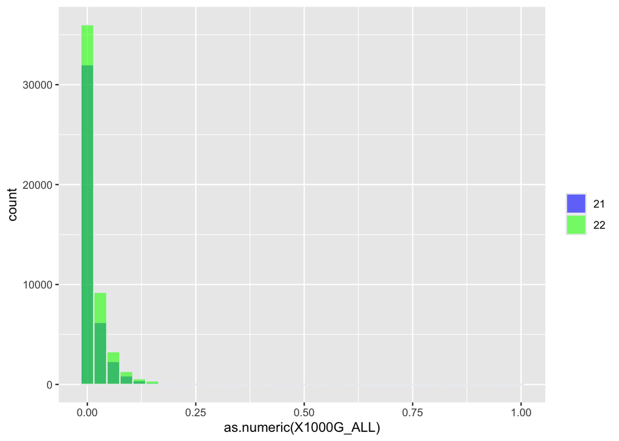

```r
p <- ggplot(final, aes(x=as.numeric(X1000G_ALL), fill=as.factor(CHR))) + geom_histogram( color="#e9ecef", binwidth = 0.03, alpha=0.6, position = 'identity') +
    scale_fill_manual(values=c("blue", "green")) +
    labs(fill="")
p
```

```r
final$Delta <- as.numeric(final$X1000G_ALL) - as.numeric(final$MAF)
```

- delta of population and samples

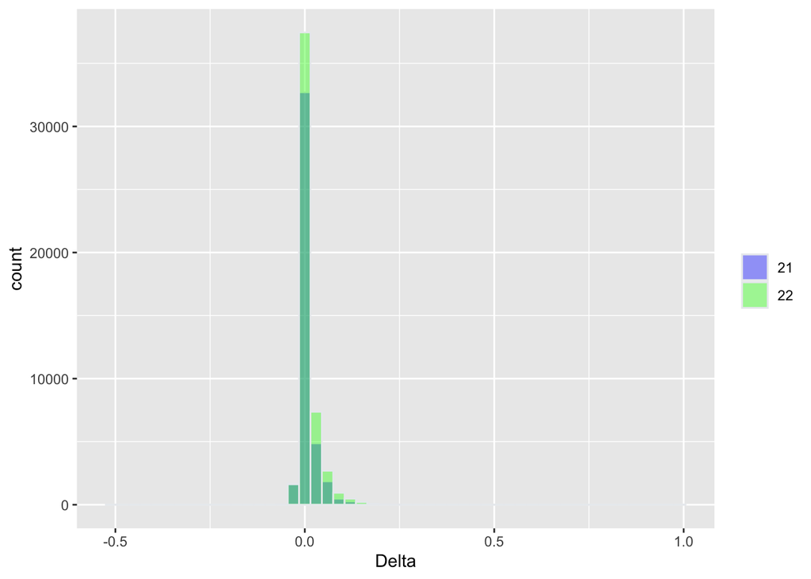

```r
p <- ggplot(final, aes(x=Delta, fill=as.factor(CHR))) + geom_histogram( color="#e9ecef", binwidth = 0.03, alpha=0.4, position = 'identity') +
    scale_fill_manual(values=c("blue", "green")) +
    labs(fill="")
p
```

Isolating just exonic regions:

```r
final_exonic <- final %>% filter(Func.refGene == "exonic")
head(final_exonic)
```

```
##   CHR      SNP                   A1      A2      MAF NCHROBS   UNADJ     GC
## 1  21 10413729                    A       G 0.493100     290 0.92870 0.9518
## 2  21 10413748                    C       T 0.003448     290 0.31730 0.4995
## 3  21 10413753                    C       T 0.482800     290 0.85630 0.9027
## 4  21 10414915 ATTCATCTTCTGAGGTTTCG AGTTTCG 0.010490     286 0.08326 0.2422
## 5  21 10454231                    G       C 0.486200     290 0.78840 0.8562
## 6  21 10541120                    T       C 0.003448     290 0.31730 0.4995
##   BONF HOLM SIDAK_SS SIDAK_SD FDR_BH FDR_BY      End     Ref
## 1    1    1        1        1 1.0000      1 10413729       G
## 2    1    1        1        1 0.3734      1 10413748       T
## 3    1    1        1        1 0.9395      1 10413753       T
## 4    1    1        1        1 0.3734      1 10414921 AGTTTCG
## 5    1    1        1        1 0.8696      1 10454231       C
## 6    1    1        1        1 0.3734      1 10541120       C
##                    Alt Func.refGene     Gene.refGene GeneDetail.refGene
## 1                    A       exonic BAGE;BAGE4;BAGE5
## 2                    C       exonic      BAGE2;BAGE3
## 3                    C       exonic      BAGE2;BAGE3
## 4 ATTCATCTTCTGAGGTTTCG       exonic            BAGE4
## 5                    G       exonic      BAGE2;BAGE3
## 6                    T       exonic             TPTE
##   ExonicFunc.refGene
## 1  nonsynonymous SNV
## 2     synonymous SNV
## 3  nonsynonymous SNV
## 4     synonymous SNV
## 5  nonsynonymous SNV
## 6  nonsynonymous SNV
##                                                                                          AAChange.refGene
## 1 BAGE:NM_001187:exon1:c.G10A:p.G4R,BAGE4:NM_181704:exon1:c.G10A:p.G4R,BAGE5:NM_182484:exon1:c.G10A:p.G4R
## 2                                     BAGE3:NM_182481:exon1:c.T9C:p.A3A,BAGE2:NM_182482:exon1:c.T9C:p.A3A
## 3                                   BAGE3:NM_182481:exon1:c.T14C:p.V5A,BAGE2:NM_182482:exon1:c.T14C:p.V5A
## 4                                                                    BAGE4:NM_181704:exon2:c.A120A:p.X40X
## 5                               BAGE3:NM_182481:exon3:c.C214G:p.P72A,BAGE2:NM_182482:exon3:c.C214G:p.P72A
## 6   TPTE:NM_199259:exon5:c.C20T:p.P7L,TPTE:NM_199260:exon5:c.C20T:p.P7L,TPTE:NM_199261:exon5:c.C20T:p.P7L
##   X1000G_ALL X1000G_AFR X1000G_AMR X1000G_EAS X1000G_EUR X1000G_SAS ExAC_Freq
## 1
## 2
## 3
## 4
```

[output cut: 190 more lines]

[output not shown]

- which gene has the most exonic regions

```r
which.max(table(final_exonic$Gene.refGene))
```

```
## CELSR1
##     88
```